# Data Mining Analysis of Airbnb Rental Properties in Monserrat Buenos Aires Argentina

## Step III: Classification

### Classification Part I: K Nearest Neighbors

The KNN predictive model was constructed using these following steps to predict certain rental properties in Monserrat will have Kitchen amenities or not.

1. Picking the third observation of rental property in Monserrat Neighborhood and removing its amenities information for test observation.

```r
rental <- data_new[3, ] %>%
  select(price, accommodates, bedrooms, beds, bathrooms, minimum_nights,
         maximum_nights, number_of_reviews, review_scores_rating, review_scores_accuracy,
         review_scores_cleanliness, review_scores_checkin, review_scores_communication,
         review_scores_location, review_scores_value, years,
         host_response_rate, host_acceptance_rate)
```

2. Building new numeric dataframe for KNN model building. The numeric predictors chosen here were price, accommodates, bedrooms, beds, bathrooms, minimum_nights, maximum_nights, number_of_reviews, review_scores_rating, review_scores_accuracy, review_scores_cleanliness, review_scores_checkin, review_scores_communication, review_scores_location, review_scores_value, years, host_response_rate, host_acceptance_rate to align with what the team has chosen previously. The predictors chosen were only numeric since KNN will rely on distance matrix for the modeling.

```r
knn_var <- data_new %>%
  select(price, accommodates, bedrooms, beds, bathrooms, minimum_nights,
         maximum_nights, number_of_reviews, review_scores_rating, review_scores_accuracy,
         review_scores_cleanliness, review_scores_checkin, review_scores_communication,
         review_scores_location, review_scores_value, years,
         host_response_rate, host_acceptance_rate, Kitchen, id)
```

3. Partitioning Dataset into Training and Validation set

```r
# Setting seed for reproducibility
set.seed(250)

# Random sampling the dataset index without replacement with 60% for training set
train_index_knn <- sample(c(1:nrow(knn_var)), nrow(knn_var)*0.6)

# Partition the dataset into training and validation set based on the index sampling
train_df_knn <- knn_var[train_index_knn, ]
valid_df_knn <- knn_var[-train_index_knn, ]
```

4. Normalizing the Dataset

Normalization was done due to the different scale for each predictor variable

```r
# Initializing normalized training, validation data, complete dataframe to originals
train_norm_df_knn <- train_df_knn
valid_norm_df_knn <- valid_df_knn
knn_var_norm<- knn_var

# Using preProcess () from the caret package to normalize predictor variables
norm_values_knn <- preProcess(train_df_knn[,1:18], method=c("center", "scale"))
train_norm_df_knn[,1:18] <- predict(norm_values_knn, train_df_knn[,1:18])
valid_norm_df_knn[,1:18] <- predict(norm_values_knn, valid_df_knn[,1:18])
knn_var_norm[,1:18] <- predict(norm_values_knn, knn_var[,1:18])

# Normalizing rental dataframe
rental_norm <- predict(norm_values_knn, rental)
```

5. Building KNN Predictive Model with arbitrary k=7

```r
# Creating knn model to predict whether rental has kitchen amenities
rental_nn <- knn(train=train_norm_df_knn[,1:18], test=rental_norm, cl=train_norm_df_knn$Kitchen, k=7)

# Checking the summary of the knn model prediction, including the 7 nearest neighbors index and distance
attributes(rental_nn)
```

```
## $levels
## [1] "1"
##
## $class
## [1] "factor"
##
## $nn.index
##      [,1] [,2] [,3] [,4] [,5] [,6] [,7]
## [1,]  174   18  113  270  104   32    4
##
## $nn.dist
##      [,1]     [,2]     [,3]    [,4]     [,5]     [,6]     [,7]
## [1,]    0 1.519194 1.690486 1.69414 1.707484 1.881108 1.909966
```

6. Determining optimal value for k

```r
# Initialize a data frame with two columns: k, and accuracy
accuracy_df_knn <- data.frame(k=seq(1,14,1), accuracy=rep(0,14))

# Compute knn for different k on validation
for(i in 1:14){
  knn.pred <- knn(train_norm_df_knn[,1:18], valid_norm_df_knn[,1:18],
                  cl = train_norm_df_knn$Kitchen, k=i)
  accuracy_df_knn[i,2] <- confusionMatrix(knn.pred, valid_norm_df_knn$Kitchen)$overall[1] %>% round(3)
}
accuracy_df_knn
```

```
##     k accuracy
## 1   1    0.951
## 2   2    0.938
## 3   3    0.960
## 4   4    0.965
## 5   5    0.951
## 6   6    0.951
## 7   7    0.947
## 8   8    0.947
## 9   9    0.947
## 10 10    0.947
## 11 11    0.947
## 12 12    0.947
## 13 13    0.947
## 14 14    0.947
```

7. Building KNN Predictive Model with optimum k=4

Optimum k=4 were chosen based on the highest accuracy when the model was tested againts the validation set.

```r
# Creating knn model to predict whether rental has kitchen amenities
rental_nn <- knn(train=train_norm_df_knn[,1:18], test=rental_norm, cl=train_norm_df_knn$Kitchen, k=4)

# Checking the summary of the knn model prediction, including the 7 nearest neighbors index and distance
attributes(rental_nn)
```

```
## $levels
## [1] "1"
##
## $class
## [1] "factor"
##
## $nn.index
##      [,1] [,2] [,3] [,4]
## [1,]  174   18  113  270
##
## $nn.dist
##      [,1]     [,2]     [,3]    [,4]
## [1,]    0 1.519194 1.690486 1.69414
```

8. Checking with actual data

```r
data_new[3,24]
```

```
## # A tibble: 1 × 1
##   Kitchen
##   <fct>
## 1 1
```

Summary

To predict whether certain rental properties in the Monserrat neighborhood had kitchen amenities or not, a KNN predictive model was constructed through a series of steps. Firstly, the third observation of a rental property in Monserrat was selected, and its amenities information was removed to create a test observation. Next, a new numeric dataframe was built for KNN model building using a range of predictors such as price, accommodates, bedrooms, beds, bathrooms, minimum_nights, maximum_nights, number_of_reviews, review_scores_rating, review_scores_accuracy, review_scores_cleanliness, review_scores_checkin, review_scores_communication, review_scores_location, review_scores_value, years, host_response_rate, and host_acceptance_rate. Only numeric predictors were chosen as KNN relies on a distance matrix for modeling.

Furthermore, the dataset was partitioned into training and validation sets, and normalization was done to account for the different scale of each predictor variable. Following this, a KNN predictive model was built with an arbitrary k value of 7. These steps laid the foundation for creating a model that could predict which rental properties in the Monserrat neighborhood would have kitchen amenities.

To refine the model, an optimal value for k was determined. This was done by testing the model against the validation set, and the highest accuracy was used to select the optimal value for k, which was found to be k=4. Finally, a KNN predictive model was built using k=4, which was then used to predict whether rental properties in the Monserrat neighborhood would have kitchen amenities or not. By using a range of predictors and an optimal k value, the KNN predictive model was able to provide accurate predictions on whether the third observation might have Kitchen amenities or not.

### Classification Part II: Naive Bayes

The Naive Bayes modeling was done through the following steps

1. Create a new dataset with variable of focus for Naive Bayes modeling

```r
# Importing data
merged2 <- data_new

# Create a vector of column names to keep
keep_vars <- c("property_type", "room_type", "accommodates", "bedrooms", "beds", "price", "minimum_nights", "maximum_nights", "number_of_reviews", "instant_bookable", "bathrooms", "shared_bathroom", "Kitchen", "Wifi", "Air_conditioning", "Elevator", "Dishes_and_silverware", "Washer", "Body_soap", "Microwave", "Paid_parking_off_premises", "host_response_rate", "host_identity_verified", "short_term_availability", "long_term_availability","review_scores_rating")

# Subset the merged2 dataframe to keep only the selected columns
merged2 <- subset(merged2, select = keep_vars)
```

2. Binning the numerical variables into categorical variables of equal frequency using cut function

```r
# Binning 'accommodates'
quantiles <- quantile(merged2$accommodates, probs = c(0.5))
breaks <- c(0, quantiles, Inf)
labels <- c("Small", "Large")
merged2$accommodates <- cut(merged2$accommodates, breaks = breaks, labels = labels)
table(merged2$accommodates)
```

```
##
## Small Large
##   304   259
```

```r
# Binning 'bedrooms'
merged2$bedrooms <- cut(merged2$bedrooms, breaks = c(0, 1, 2, Inf), labels = c("1-2", "3-4", "5+"))

# Binning 'beds'
merged2$beds <- cut(merged2$beds, breaks = c(0, 1, 2, Inf), labels = c("1-2", "3-4", "5+"))

# Binning 'bathrooms'
merged2$bathrooms <- cut(merged2$bathrooms, breaks = c(0, 1, 2, 3, Inf), labels = c("1", "2", "3", "4+"))

# Binning 'minimum_nights'
merged2$minimum_nights <- cut(merged2$minimum_nights + runif(nrow(merged2), -0.0001, 0.0001),
                              breaks = quantile(merged2$minimum_nights + runif(nrow(merged2), -0.0001, 0.0001), probs = seq(0, 1, 0.25)),
                              labels = c("1", "2", "3", "4+"))

# Add small amount of noise to 'maximum_nights'
merged2$maximum_nights <- merged2$maximum_nights + runif(nrow(merged2), -0.0001, 0.0001)
# Binning 'maximum_nights'
merged2$maximum_nights <- cut(merged2$maximum_nights, breaks = quantile(merged2$maximum_nights, probs = seq(0, 1, 0.25)), labels = c("1-3", "4-7", "8-14", "15+"))
# Binning 'number_of_reviews'
merged2$number_of_reviews <- cut(merged2$number_of_reviews, breaks = quantile(merged2$number_of_reviews, probs = seq(0, 1, 0.25)), labels = c("1-7", "8-23", "24-56", "57+"))
# Binning 'host_response_rate'
merged2$host_response_rate <- cut(jitter(merged2$host_response_rate),
                                  breaks = quantile(jitter(merged2$host_response_rate),
                                                    probs = seq(0, 1, 0.25),
                                                    na.rm = TRUE),
                                  labels = c("<75%", "75-94%", "95-99%", "100%"))
# Binning 'review_scores_rating'
# Add jitter to the data
merged2$review_scores_rating<- jitter(merged2$review_scores_rating, amount = 0.001)
quantiles <- quantile(merged2$review_scores_rating, probs = seq(0, 1, 0.25), na.rm = TRUE)

if (length(unique(quantiles)) == length(quantiles)) {
  # Bin the data
  merged2$review_scores_rating <- cut(merged2$review_scores_rating,
                                      breaks = quantiles,
                                      labels = c("<80", "80-90", "90-95", "95+"),
                                      include.lowest = TRUE)
} else {
  cat("Quantiles are not unique. Please consider using different probabilities or jitter amount.")
}

# Binning 'Price'
# Calculate the quantiles for equal frequency binning
quantiles <- quantile(merged2$price, probs = seq(0, 1, length.out = 3 + 1), na.rm = TRUE, type = 5)
# Generate labels for the bins
bin_labels <- c("Low", "Medium", "High")
# Bin the data
merged2$price <- cut(merged2$price, breaks = quantiles, labels = bin_labels, include.lowest = TRUE)
```

3. Creating Proportional Barplot for Feature Selection to be loaded into Naive Bayes Model

```r
# Select the categorical variables
variables <- c("property_type", "room_type", "accommodates", "bedrooms", "beds", "price", "minimum_nights", "maximum_nights", "number_of_reviews", "bathrooms", "shared_bathroom", "Kitchen", "Wifi", "Air_conditioning", "Elevator", "Dishes_and_silverware", "Washer", "Body_soap", "Microwave", "Paid_parking_off_premises", "host_response_rate", "host_identity_verified", "short_term_availability", "long_term_availability", "review_scores_rating")

# Reshape the dataset
merged2_long <- merged2 %>%
  select(one_of(variables), instant_bookable) %>%
  gather(key = "variable", value = "value", -instant_bookable)
```

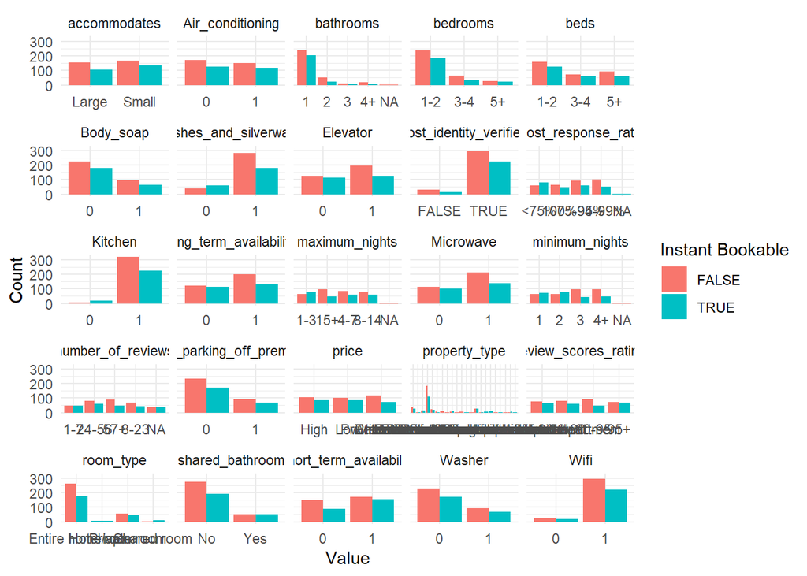

```r
# Create the faceted barplot
p <- ggplot(merged2_long, aes(x = value, fill = instant_bookable)) +
  geom_bar(position = "dodge") +
  theme_minimal() +
  facet_wrap(~variable, scales = "free_x", ncol = 5) +
  xlab("Value") +
  ylab("Count") +
  scale_fill_discrete(name = "Instant Bookable")

print(p)
```

4. Removing Variable with Weak Predictive Power

```r
# List of variables to remove
variables_to_remove <- c("long_term_availability", "short_term_availability", "Air_conditioning", "number_of_reviews", "price", "minimum_nights", "review_scores_rating")

# Remove the variables
merged2 <- merged2 %>%
  select(-one_of(variables_to_remove))
```

5. Building the Naive Bayes Prediction Model

```r
# Set the seed for reproducibility
set.seed(42)

# Create an 60-40 split for training and testing sets
train_index <- createDataPartition(merged2$instant_bookable, p = 0.6, list = FALSE)
train_set <- merged2[train_index, ]
test_set <- merged2[-train_index, ]

# Build the Naive Bayes model using naiveBayes() function
nb_model <- naiveBayes(instant_bookable ~ ., data = train_set)

# Summary of the model
print(nb_model)
```

```
##
## Naive Bayes Classifier for Discrete Predictors
##
## Call:
## naiveBayes.default(x = X, y = Y, laplace = laplace)
##
## A-priori probabilities:
## Y
##     FALSE      TRUE
## 0.5739645 0.4260355
##
## Conditional probabilities:
##        property_type
## Y       Entire condo Entire home Entire loft Entire rental unit
##   FALSE  0.139175258 0.005154639 0.041237113        0.551546392
##   TRUE   0.111111111 0.006944444 0.048611111        0.423611111
##        property_type
## Y       Entire serviced apartment Entire vacation home
##   FALSE               0.056701031          0.020618557
##   TRUE                0.083333333          0.013888889
##        property_type
## Y       Private room in bed and breakfast Private room in casa particular
##   FALSE                       0.030927835                     0.010309278
##   TRUE                        0.000000000                     0.000000000
##        property_type
## Y       Private room in condo Private room in guesthouse Private room in home
##   FALSE           0.015463918                0.000000000          0.020618557
##   TRUE            0.055555556                0.000000000          0.000000000
##        property_type
## Y       Private room in hostel Private room in pension
##   FALSE            0.000000000             0.005154639
##   TRUE             0.006944444             0.000000000
##        property_type
## Y       Private room in rental unit Private room in serviced apartment
##   FALSE                 0.077319588                        0.015463918
##   TRUE                  0.104166667                        0.006944444
##        property_type
## Y       Room in hostel Room in hotel Shared room in condo Shared room in hostel
##   FALSE    0.000000000   0.000000000          0.000000000           0.000000000
##   TRUE     0.034722222   0.055555556          0.000000000           0.013888889
```

[output cut: 78 more lines]

```
##
##        Paid_parking_off_premises
## Y               0         1
##   FALSE 0.6907216 0.3092784
##   TRUE  0.6875000 0.3125000
##
##        host_response_rate
## Y            <75%    75-94%    95-99%      100%
##   FALSE 0.1907216 0.2938144 0.3350515 0.1804124
##   TRUE  0.3496503 0.2377622 0.2097902 0.2027972
##
##        host_identity_verified
## Y            FALSE       TRUE
##   FALSE 0.08247423 0.91752577
##   TRUE  0.06944444 0.93055556
```

```r
# Generate predictions for the test set
predictions <- predict(nb_model, test_set)

# Convert predictions and test_set$instant_bookable to factors
predictions_factor <- factor(predictions, levels = c("FALSE", "TRUE"))
test_set_factor <- factor(test_set$instant_bookable, levels = c("FALSE", "TRUE"))

# Create the confusion matrix
cm <- confusionMatrix(predictions_factor, test_set_factor)

# Print the confusion matrix
print(cm)
```

```
## Confusion Matrix and Statistics
##
##           Reference
## Prediction FALSE TRUE
##      FALSE    96   60
##      TRUE     33   36
##
##                Accuracy : 0.5867
##                  95% CI : (0.5193, 0.6517)
##     No Information Rate : 0.5733
##     P-Value [Acc > NIR] : 0.369214
##
##                   Kappa : 0.1236
##
##  Mcnemar's Test P-Value : 0.007016
##
##             Sensitivity : 0.7442
##             Specificity : 0.3750
##          Pos Pred Value : 0.6154
##          Neg Pred Value : 0.5217
##              Prevalence : 0.5733
##          Detection Rate : 0.4267
##    Detection Prevalence : 0.6933
##       Balanced Accuracy : 0.5596
##
##        'Positive' Class : FALSE
##
```

6. Prediction Fictional Apartment

```r
#b.
# Create a data frame for the fictional apartment
# Create a data frame for the fictional apartment
kalibataCity <- data.frame(
  property_type = "Entire rental unit",
  room_type = "Entire home/apt",
  accommodates = "Small",
  bedrooms = "1-2",
  beds = "1-2",
  maximum_nights = "4-7",
  bathrooms = "1",
  shared_bathroom = "No",
  Kitchen = "1",
  Wifi = "1",
  Elevator = "0",
  Dishes_and_silverware = "1",
  Washer = "0",
  Body_soap = "1",
  Microwave = "1",
  Paid_parking_off_premises = "1",
  host_response_rate = "95-99%",
  host_identity_verified = "TRUE"
)

# Make the prediction
prediction <- predict(nb_model, kalibataCity)

# Print the prediction result
print(prediction)
```

```
## [1] FALSE
## Levels: FALSE TRUE
```

Summary

To build a predictive model, the first step involved data preprocessing and cleaning, where we transformed certain variables into numeric variables and binned numerical variables using equal frequency. Additionally, we converted several variables into factor data types to make them suitable for input in the Naive Bayes model. We also removed some index variables, including names, as they would not be meaningful in the model. Once the data was prepared, we proceeded to the feature selection stage, where we created bar plots for all the remaining variables to evaluate their distribution. If the distribution of a variable was relatively similar, we considered it to have low predictive power and removed it from the model.

The model returned a prediction of “FALSE,” indicating that, based on the given features, this specific apartment may not qualify as an instant bookable property.

### Classification Part III: Classification Tree

Classification Tree predictive model was built through the following steps:

1. Preparing the data for Classification Tree Model

```r
# binning rating into three
merged <- data_new %>%
  mutate(rating_bin = ntile(review_scores_rating, 3))
merged$rating_bin <- factor(merged$rating_bin, labels = c("low","medium","high"))
table(merged$rating_bin)
```

```
##
##    low medium   high
##    188    188    187
```

```r
# remove ID, name, latitude, longitude, host_id, because index is irrelevant. Prepare other variable for the tree model input
merged <- select(merged, -c(id, name, latitude, longitude, host_id,review_scores_rating))
merged$host_acceptance_rate[merged$host_acceptance_rate == "N/A"] <- 0
merged$host_acceptance_rate <- as.numeric(gsub("%", "", merged$host_acceptance_rate))
merged$host_response_rate[merged$host_response_rate == "N/A"] <- 0
merged$host_response_rate <- as.numeric(gsub("%", "", merged$host_response_rate))

# binning property type because the it contain so many variable. It will be bin into Entire Home, Private Room and Other
merged <- merged %>%
  mutate(property_type_bin = case_when(
    property_type %in% c("Entire home", "Entire apartment", "Entire condo", "Entire serviced apartment", "Entire villa", "Entire townhouse") ~ "Entire Home",
    property_type %in% c("Private room in rental unit", "Private room in condo", "Private room in home", "Private room in serviced apartment", "Private room in villa", "Private room in townhouse") ~ "Private Room",
    TRUE ~ "Other"
  ))
merged <- select(merged, -property_type)

# remove all review scores column because it redundant with review scores rating
merged <- subset(merged, select = -c(review_scores_accuracy, review_scores_cleanliness, review_scores_checkin, review_scores_location, review_scores_value,review_scores_communication))
```

2. Building the Classification Tree

```r
# Split the data into training and testing sets
set.seed(123)
train_idx <- sample(nrow(merged), 0.6*nrow(merged))
train_data <- merged[train_idx, ]
test_data <- merged[-train_idx, ]

# Define the control parameters for tree building
ctrl <- rpart.control(minsplit = 20, xval = 10)

# Build the tree with cross-validation
tree_fit <- rpart(rating_bin ~ ., data = train_data, method = "class", control = ctrl)
printcp(tree_fit)
```

```
##
## Classification tree:
## rpart(formula = rating_bin ~ ., data = train_data, method = "class",
##     control = ctrl)
##
## Variables actually used in tree construction:
##  [1] bedrooms                  host_acceptance_rate
##  [3] host_is_superhost         Microwave
##  [5] number_of_reviews         Paid_parking_off_premises
##  [7] price                     room_type
##  [9] short_term_availability   years
##
## Root node error: 223/337 = 0.66172
##
## n= 337
##
##         CP nsplit rel error  xerror     xstd
## 1 0.295964      0   1.00000 1.10762 0.036421
## 2 0.071749      1   0.70404 0.71749 0.041108
## 3 0.017937      2   0.63229 0.68161 0.040963
## 4 0.015695      5   0.57848 0.72197 0.041120
## 5 0.013453      7   0.54709 0.72197 0.041120
## 6 0.011211     10   0.50673 0.73094 0.041139
## 7 0.010000     12   0.48430 0.73094 0.041139
```

```r
# Determine the optimal CP value
optimal_cp <- tree_fit$cptable[which.min(tree_fit$cptable[,"xerror"]),"CP"]
optimal_cp
```

```
## [1] 0.01793722
```

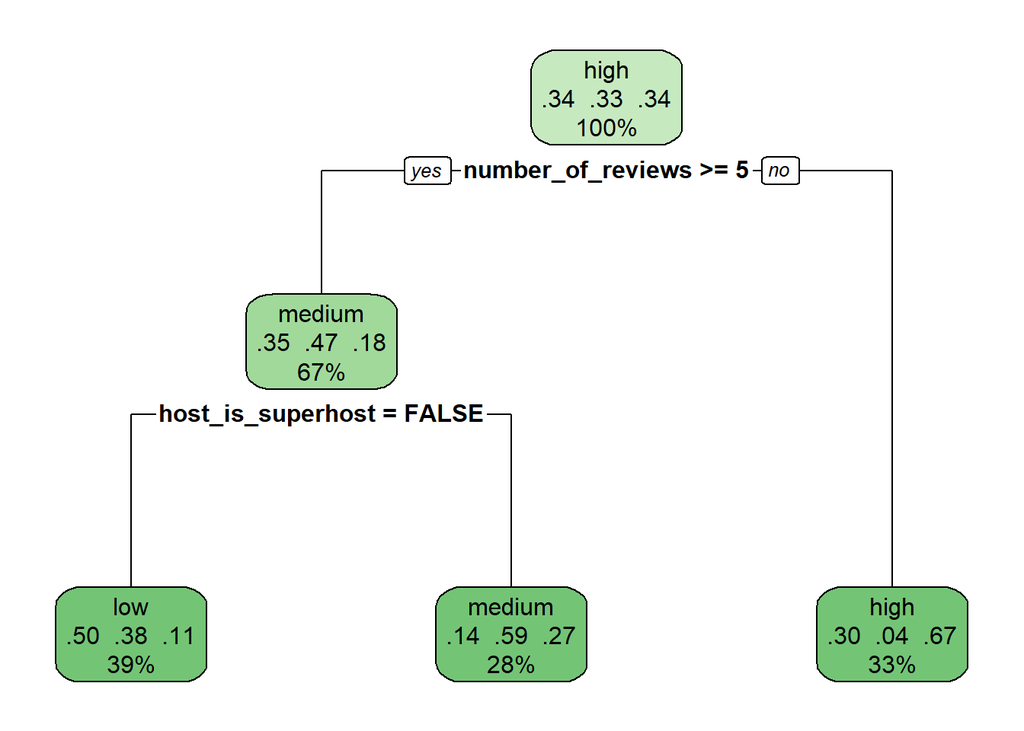

```r
# Prune the tree with the optimal CP value
pruned_tree_fit <- prune(tree_fit, cp = optimal_cp)


##C.
# Plot the pruned tree
rpart.plot(pruned_tree_fit, box.palette = "Greens")
```

```r
# Predict on test data and build confusion matrix
test_pred <- predict(pruned_tree_fit, test_data, type = "class")
confusionMatrix(test_data$rating_bin, test_pred)
```

```
## Confusion Matrix and Statistics
##
##           Reference
## Prediction low medium high
##     low     42      2   31
##     medium  33     44    1
##     high    12      8   53
##
## Overall Statistics
##
##                Accuracy : 0.615
##                  95% CI : (0.5482, 0.6788)
##     No Information Rate : 0.385
##     P-Value [Acc > NIR] : 2.319e-12
##
##                   Kappa : 0.424
##
##  Mcnemar's Test P-Value : 5.656e-09
##
## Statistics by Class:
##
##                      Class: low Class: medium Class: high
## Sensitivity              0.4828        0.8148      0.6235
## Specificity              0.7626        0.8023      0.8582
## Pos Pred Value           0.5600        0.5641      0.7260
## Neg Pred Value           0.7020        0.9324      0.7908
## Prevalence               0.3850        0.2389      0.3761
## Detection Rate           0.1858        0.1947      0.2345
## Detection Prevalence     0.3319        0.3451      0.3230
## Balanced Accuracy        0.6227        0.8086      0.7408
```

```r
table(test_data$rating_bin, test_pred)
```

```
##         test_pred
##          low medium high
##   low     42      2   31
##   medium  33     44    1
##   high    12      8   53
```

```r
# Create confusion matrix
conf_mat <- confusionMatrix(test_data$rating_bin, test_pred)

# Print the accuracy
conf_mat
```

```
## Confusion Matrix and Statistics
##
##           Reference
## Prediction low medium high
##     low     42      2   31
##     medium  33     44    1
##     high    12      8   53
##
## Overall Statistics
##
##                Accuracy : 0.615
##                  95% CI : (0.5482, 0.6788)
##     No Information Rate : 0.385
##     P-Value [Acc > NIR] : 2.319e-12
##
##                   Kappa : 0.424
##
##  Mcnemar's Test P-Value : 5.656e-09
##
## Statistics by Class:
##
##                      Class: low Class: medium Class: high
## Sensitivity              0.4828        0.8148      0.6235
## Specificity              0.7626        0.8023      0.8582
## Pos Pred Value           0.5600        0.5641      0.7260
## Neg Pred Value           0.7020        0.9324      0.7908
## Prevalence               0.3850        0.2389      0.3761
## Detection Rate           0.1858        0.1947      0.2345
## Detection Prevalence     0.3319        0.3451      0.3230
## Balanced Accuracy        0.6227        0.8086      0.7408
```

Summary

In developing a classification tree model to predict Airbnb listing ratings, various features were evaluated for their potential influence on the ratings. The dataset contained attributes such as host acceptance rate, host response rate, and property types, among others. These features were considered relevant since they could impact guests’ experiences and subsequently affect their ratings. To facilitate model building, cleaning and preprocessing steps were carried out, including converting percentages to numeric values, remove indexing variables and categorizing property types into broader groups.

During the exploration of different models, an interesting observation was the trade-off between the number of bins and model accuracy. It was noticed that increasing the number of bins could lead to reduced accuracy due to overfitting and data imbalance. To address this issue, the ratings were divided into three bins: low, medium, and high with equal frequency. This distribution may have impacted the model’s performance, as a slight imbalance in the data can affect the model’s ability to generalize to unseen data.

## Step IV: Clustering

0. Process for Variable Selection & Model Building

First, k-means clustering is chosen as the clustering model between hierarchical clustering and k-means clustering due to computational efficiency of k-means clustering in calculating 563 observations of 41 variables.

Second, as k-means clustering is chosen, only numeric values are passed onto the model and categorical data such as name, latitude & longitude, and host_response_time, are dropped. For any values that could turn into numeric values, such as host_acceptance_rate and host_response_rate, were converted into numeric values after data manipulation.

Third, an elbow chart is created to see the general trend of total within-cluster sum of squares per the number of clusters. Because there was not a clear kink in the chart, a manual observation of data for centers for different k’s is conducted. According to the analysis, any number of clusters with k equal and above 4 does not provide discernible information for interpretation. Hence, k=3 was chosen as the number of models.

1. Preparing data for clustering analysis

```r
cluster <- as.data.frame(data_new)
row.names(cluster) <- cluster[,1]
cluster <- cluster[,-1]

#Select numeric variables only
num_var <- cluster %>% select(price, accommodates, bedrooms, beds, bathrooms, minimum_nights, maximum_nights, number_of_reviews, review_scores_rating, review_scores_accuracy, review_scores_cleanliness, review_scores_checkin, review_scores_communication, review_scores_location, review_scores_value, years, host_response_rate, host_acceptance_rate)

#Change from string type to numeric type
num_var$host_response_rate <- gsub("%", "", num_var$host_response_rate)
num_var$host_acceptance_rate <- gsub("%", "", num_var$host_acceptance_rate)
num_var <- num_var %>%
  mutate(host_response_rate = as.numeric(gsub("%", "",host_response_rate)), host_acceptance_rate = as.numeric(gsub("%", "", host_acceptance_rate)))

#Normalize the data
num_var.norm <- sapply(num_var, scale)
row.names(num_var.norm) <- row.names(num_var)
```

2. Building Elbow Plot for Initial Analysis on Number of Cluster

```r
#Create an elbow chart
set.seed(699)
kmax <- 30
wss <- sapply(1:kmax,
              function(k){kmeans(num_var.norm, k, nstart=50, iter.max = 30)$tot.withinss})
wss
```

```
##  [1] 10116.000  8429.449  7616.664  7076.054  6628.485  6125.637  5818.640
##  [8]  5372.863  5075.328  4832.822  4670.326  4472.784  4334.985  4206.636
## [15]  4079.128  3973.216  3835.034  3743.977  3649.898  3579.884  3472.252
## [22]  3375.344  3297.592  3244.817  3169.741  3123.603  3011.214  2981.595
## [29]  2919.982  2855.981
```

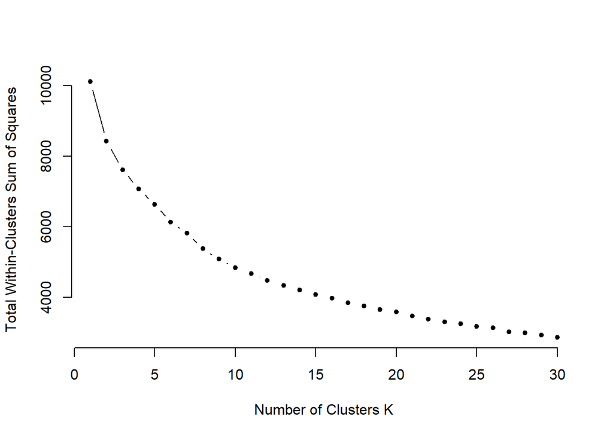

```r
plot(1:kmax, wss, type = "b", pch = 20, frame = FALSE, xlab = "Number of Clusters K", ylab = "Total Within-Clusters Sum of Squares")
```

By looking at the elbow plot, it is safe to start iterating from k=3 to k=7, but after iterating it in separate script we found that k equals to 3 could splits the data best and provide easy to understand output. Therefore we chose k=3 for this cluster model.

3. Building k-means clustering model

```r
#Kmeans clustering with k=3
km3 <- kmeans(num_var.norm, 3, nstart=50)
km3$centers
```

```
##         price accommodates    bedrooms        beds  bathrooms minimum_nights
## 1 -0.05216086   -0.0579185 -0.07405650 -0.07866686 -0.1192584    -0.01767926
## 2  3.43436992    4.0524905  3.89702259  4.12784817  4.3102872    -0.01684691
## 3 -0.13807876   -0.1906681 -0.04307181 -0.04391231  0.2377260     0.13771294
##   maximum_nights number_of_reviews review_scores_rating review_scores_accuracy
## 1   -0.005842408        0.05900992            0.2703180              0.2762133
## 2    0.780449770       -0.14880293           -0.2114711             -0.1003965
## 3   -0.077305625       -0.42762224           -2.0323565             -2.0947554
##   review_scores_cleanliness review_scores_checkin review_scores_communication
## 1                 0.2411751            0.21885475                   0.2046853
## 2                -0.1389053            0.02615551                   0.2839105
## 3                -1.8210242           -1.67627386                  -1.6082843
##   review_scores_location review_scores_value       years host_response_rate
## 1              0.1691286          0.24683558  0.02136485         0.03503417
## 2              0.2449943          0.08942202  0.23236188         0.09035211
## 3             -1.3305285         -1.89995029 -0.19954732        -0.28180045
##   host_acceptance_rate
## 1           0.06116284
## 2          -0.91962408
## 3          -0.32363103
```

```r
cluster3 <- km3$cluster

# Checking the cluster distance
dist(km3$centers)
```

```
##           1         2
## 2  9.186936
## 3  5.443384 10.239104
```

```r
# Binding the cluster label back to original data
num_var.norm <- cbind(num_var.norm, cluster)
cluster <- cbind(cluster, cluster3)
head(cluster)
```

```
##                                                      name  latitude longitude
## 16695                           DUPLEX LOFT 2 - SAN TELMO -34.61439 -58.37611
## 148284                Sunny Terrace Apart. in Downtown BA -34.61331 -58.38491
## 23798   STUNNING-LIGHT-SPACIOUS LOFT STYLE APT- SAN TELMO -34.61266 -58.37479
## 31514                     BEAUTY DUPLEX LOFT #4 SAN TELMO -34.61494 -58.37517
## 42450  French Classic in San Telmo: Balcony over Defensa! -34.61578 -58.37175
## 362556                   Sunny Terrace Apart in Center BA -34.61554 -58.38486
##             property_type       room_type price accommodates bedrooms beds
## 16695         Entire loft Entire home/apt 10354            4        1    1
## 148284 Entire rental unit Entire home/apt  6833            4        1    1
## 23798        Entire condo Entire home/apt 14501            3        2    3
## 31514         Entire loft Entire home/apt  9347            5        1    4
## 42450        Entire condo Entire home/apt 16152            4        2    2
## 362556 Entire rental unit Entire home/apt 10354            4        1    2
##        bathrooms shared_bathroom minimum_nights maximum_nights
```

[output cut: 69 more lines]

4. Naming the cluster
- Cluster1: Well-reviewed & Steady

The number of reviews and review scores across the board are generally highest among three clusters, indicating the number of reviews prove the quality of listening per described.

- Cluster2: Big Vacay

The price, number of accommodates, bedrooms, beds, and bathrooms are highest. It indicates that the listings in Cluster2 may involve the full house designed for a group of friends or a family trip.

- Cluster3: Cheap & Shady

The price of cluster 3 is placed the lowest and the number of reviews and review scores across the board are the worst.

5. Visualizing the Cluster: Line Plot

```r
dev.new(width = 12, height = 50)

# Plot the data with x-axis labels
plot(c(0), xaxt = 'n', ylab = "", type = "l", xlab = "", main = "Profile Plot of Centroids",
     ylim = c(min(km3$centers), max(km3$centers)), xlim = c(0,18))

axis(1, at = c(1:18), labels = names(num_var), las = 2, cex.axis = 0.6)

lines(km3$centers[1,], lty = 1, lwd = 2, col = "red")
lines(km3$centers[2,], lty = 2, lwd = 2, col = "blue")
lines(km3$centers[3,], lty = 3, lwd = 2, col = "green")

clusters = c("Well-Reviewed & Steady", "Big Vacay", "Cheap & Shady")
text(x = rep(0.5, 2)+1.8, y = c(km3$centers[1,1]+0.5, km3$centers[2,1], km3$centers[3,1]-0.3),
     labels = clusters)
mtext("Index", side = 1, line = 10, cex = 0.8)
```

[output not shown]

6. Visualizing Cluster: Scatter Plot

```r
dev.new(width = 15, height = 50)
cluster$cluster_label <- ifelse(cluster$cluster3 == 1, clusters[1],
                                  ifelse(cluster$cluster3 == 2, clusters[2], clusters[3]))

cluster$cluster_label <- cluster$cluster_label %>% as.factor()

discretionary <- cluster %>% group_by(cluster_label) %>%
  summarize(mean_price = mean(price),
            mean_review_scores_rating = mean(review_scores_rating))

ggplot(data = discretionary, aes(x = mean_price, y = mean_review_scores_rating, color = factor(cluster_label))) +
  geom_point(size = 4) +
  scale_color_manual(values = c("purple", "orange", "green")) +
  theme_classic() +
  labs(x = "Average Price", y = "Average Review Scores Rating", color = "Clusters", title = "Comparison between Average Price and Average Review Scores Rating") +
  geom_text(aes(label = cluster_label),
            hjust = 0.1, vjust = 2, size = 3) +
  scale_y_continuous(limits = c(0, max(discretionary$mean_review_scores_rating) + 1))
```

[output not shown]

7. Visualizing Cluster: Countplot

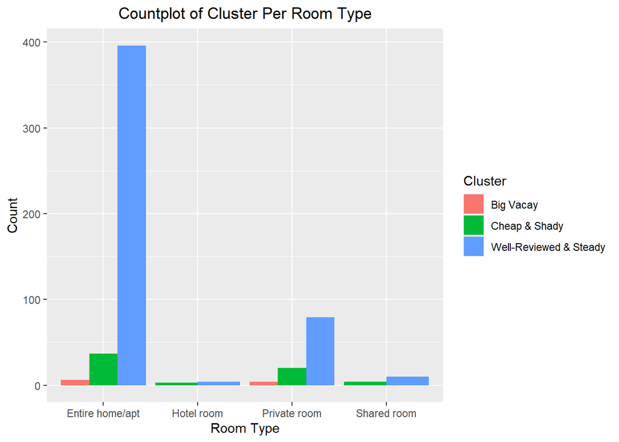

```r
ggplot(cluster, aes(x = room_type, fill = cluster_label)) + geom_bar(position = "dodge") +
  labs(x = "Room Type", y = "Count", fill = "Cluster", title = "Countplot of Cluster Per Room Type") +theme(plot.title = element_text(hjust = 0.5))
```

Description

The count plot above illustrates the number of values in each cluster per room type. As shown, the values of Cluster “Well-Reviewed & Steady” predominantly occupy entire home/apartment type and Cluster “Big Vacay” does not exist in the room type of hotel room and shared room.

## Step V: Conclusions

The data mining analysis output is a valuable asset for both property owners and prospective tenants in Monserrat. It provides both groups with data-driven insights to make informed decisions about renting and owning property.

For property owners, the data mining analysis output can help improve the service they offer by identifying the features that prospective tenants value the most. By analyzing historical data, the analysis can identify the most sought-after features in a rental property such as location, amenities, and condition. Property owners can use this information to improve their rental offerings and attract more tenants. Additionally, the analysis can provide insights into rental prices and help property owners set prices that match the market and prospective tenants’ expectations.

For prospective tenants, the data mining analysis output can help them easily choose rental properties that match their needs. The clustering model can help tenants identify properties that meet their specific requirements based on location, size, amenities, and other factors. This can save tenants time and effort by narrowing down the available options and selecting only the most suitable properties. Additionally, the analysis can help tenants negotiate better prices by providing insights into the market value of specific rental properties. Finally, by analyzing the features of rental properties, prospective tenants can predict the level of service they can expect from their landlords and make informed decisions about which properties to rent.

In conclusion, the data mining analysis output is an invaluable asset for both property owners and prospective tenants in Montserrat. By providing insights into rental prices, rental features, and service levels, the analysis can help both parties achieve their goals and make data-driven decisions. Ultimately, this can lead to a more efficient and effective rental market that benefits everyone involved.